# Series temporelles avec *Keras*

On teste ici differentes modelisations a base de reseaux neuronaux sous TensorFlow et on les compare a des modeles de regression classiques.

# 1 Modules et donnees

```r
library("reticulate")

use_condaenv(condaenv = "env_tf26")
```

## 1.1 Modules

```python
import numpy as np
import pandas as pd
pd.set_option('display.max_columns', None)

import math
import sys

from sklearn.model_selection import train_test_split
from sklearn.linear_model import LinearRegression
from sklearn.metrics import mean_squared_error

import statsmodels.api as sm

import tensorflow as tf
from tensorflow.keras import layers
from tensorflow.keras.layers import Dense, GRU, Dropout, SimpleRNN
from tensorflow.keras.models import Sequential
from tensorflow.keras.callbacks import EarlyStopping

# https://github.com/philipperemy/keras-tcn
from tcn import TCN

# pour regler un bug graphique assez courant avec Anaconda,
# adapter le chemin vers le dossier 'plugins/platforms'
import os
from os import path
os.environ['QT_QPA_PLATFORM_PLUGIN_PATH'] = 'C:/Users/Sebastien/Anaconda3/Library/plugins/platforms'
os.chdir(".")

import matplotlib.pyplot as plt
import seaborn as sns
sns.set()

tf.random.set_seed(2021)

# calcul de la rmse
def rmse(u,v):
  return int(mean_squared_error(u,v)**1/2)
```

Les versions Python et TensorFlow utilisees.

```python
sys.version
tf.__version__
```

```
'3.9.6 (default, Jul 30 2021, 11:42:22) [MSC v.1916 64 bit (AMD64)]'
'2.6.0'
```

## 1.2 Description des donnees Airline Passenger

Il s’agit du nombre mensuel de passagers du secteur aerien de 1949 a 1960, donnees qu’on a deja utilise pour tester le module *prophet* dans un autre document.

```r
donnees_r = data.frame(AirPassengers)
donnees_r["Month"] = c(sapply(1949:1960, function(x) paste(x, month.abb)))
donnees_r["Passengers"] = donnees_r$AirPassengers
donnees_r$AirPassengers = NULL
```

```python
donnees = r.donnees_r
donnees.head()
```

```
      Month  Passengers
0  1949 Jan       112.0
1  1949 Feb       118.0
2  1949 Mar       132.0
3  1949 Apr       129.0
4  1949 May       121.0
```

```python
donnees.rename(columns = {'Passengers':'X'}, inplace = True)
donnees.X = donnees.X.astype('float32')
donnees.reset_index(drop = True)
```

```
        Month      X
0    1949 Jan  112.0
1    1949 Feb  118.0
2    1949 Mar  132.0
3    1949 Apr  129.0
4    1949 May  121.0
..        ...    ...
139  1960 Aug  606.0
140  1960 Sep  508.0
141  1960 Oct  461.0
142  1960 Nov  390.0
143  1960 Dec  432.0

[144 rows x 2 columns]
```

La serie est multiplicative avec une saisonnalite de periode 12 et la tendance est lineaire par morceaux.

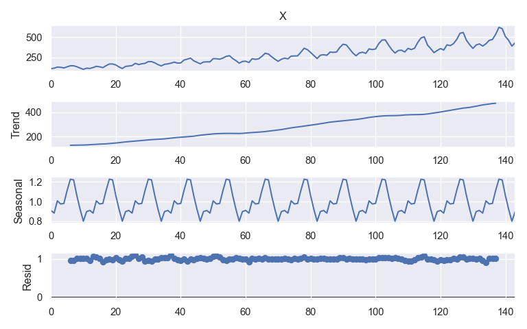

```python
periode = 12
decomposition = sm.tsa.seasonal_decompose(donnees.X, model='multiplicative', period = 12)
decomposition.plot()
plt.show()
```

# 2 Modelisation par tendance et saisonnalite

On definit une colonne “partition” pour scinder les donnees en jeux d’apprentissage (`donnees.partition == True`) et de test, l’apprentissage allant jusqu’a mars 1956.

```python
donnees["partition"] = pd.Series(donnees.index) <= 0.6 * len(donnees)
donnees["partition"].value_counts()
```

```
True     87
False    57
Name: partition, dtype: int64
```

## 2.1 Modele lineaire

On se place d’avril 1953 a mars 1956, soit les 3 dernieres annees de l’apprentissage, pour obtenir une tendance par moyenne mobile et une saisonnalite les plus fiables afin de realiser une prevision par regression lineaire.

```python
# X = tendance * saisonnalite * bruit

# profondeur de calcul de la tendance a partir des donnees recentes de l'apprentissage
K = 12 * 3

dtf = donnees[donnees.partition].copy()
dtf = dtf[-K:]

decomposition = sm.tsa.seasonal_decompose(dtf.X, model='multiplicative', period = periode)

dtf["temps"] = list(dtf.index)
dtf["tendance"] = decomposition.trend
dtf
```

```
       Month      X  partition  temps    tendance
51  1953 Apr  235.0       True     51         NaN
52  1953 May  229.0       True     52         NaN
53  1953 Jun  243.0       True     53         NaN
54  1953 Jul  264.0       True     54         NaN
55  1953 Aug  272.0       True     55         NaN
56  1953 Sep  237.0       True     56         NaN
57  1953 Oct  211.0       True     57  224.583333
58  1953 Nov  180.0       True     58  224.458333
59  1953 Dec  201.0       True     59  225.541667
60  1954 Jan  204.0       True     60  228.000000
61  1954 Feb  188.0       True     61  230.458333
62  1954 Mar  235.0       True     62  232.250000
63  1954 Apr  227.0       True     63  233.916667
64  1954 May  234.0       True     64  235.625000
```

[output cut: 22 more lines]

On modelise lineairement la tendance et on recupere la saisonnalite calculee par *statsmodels*, ce qui permet d’en deduire la serie residuelle.

```python
debut_saison = (dtf.temps.min() // periode + 1) * periode

saisons = list(decomposition.seasonal.loc[debut_saison:(debut_saison + periode - 1)])
repet_saisons = len(donnees) // periode + 1

dtf.dropna(inplace = True)

reg = LinearRegression();
reg.fit(dtf[["temps"]], dtf.tendance);

donnees["tendance"] = reg.predict(pd.Series(range(len(donnees))).to_frame())
donnees["saisons"] = (saisons*repet_saisons)[:len(donnees)]
donnees["residus"] = donnees.X / donnees.tendance / donnees.saisons
```

## 2.2 Qualite du modele

La tendance lineaire, les residus et la serie de donnees complete, on voit qu’avant avril 1953 la tendance avait une pente differente.

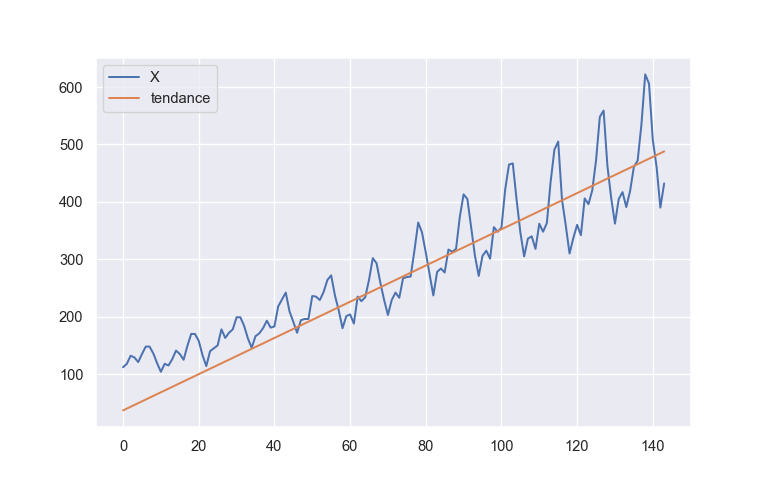

```python
donnees[["X", "tendance"]].plot();
plt.show()
```

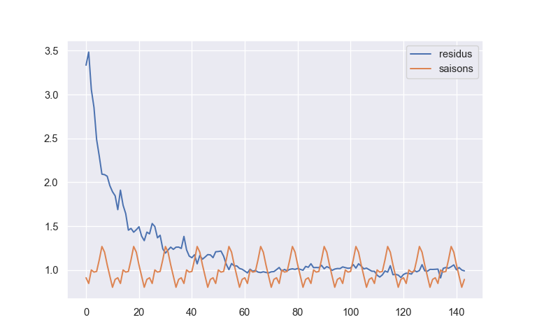

```python
donnees[["residus", "saisons"]].plot();
plt.show()
```

On prevoit les 57 valeurs du futur en une fois par une modelisation parametrique simple.

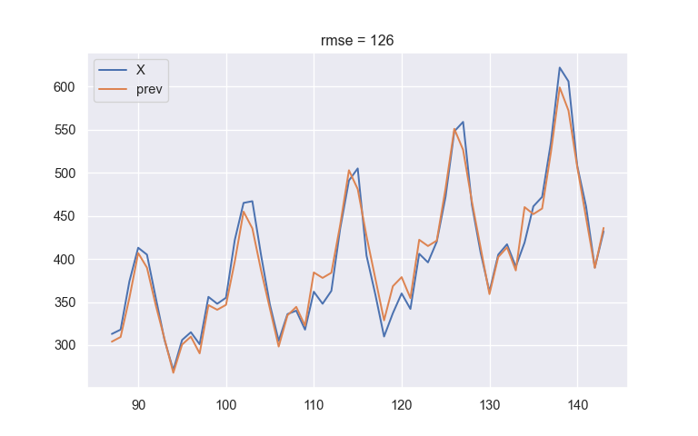

```python
donnees["prev"] = donnees.tendance * donnees.saisons
test = ~donnees.partition
donnees.loc[test, ["X", "prev"]].plot();
plt.title(f"rmse = {rmse(donnees.prev[test], donnees.X[test])}");
plt.show()
```

# 3 Prevision du mois suivant par modeles neuronaux

On va proceder de deux manieres a partir de la connaissance des *K* derniers mois :

- par regression lineaire et par couche Dense appliquees a *K* variables (on peut utiliser tout modele de regression de Machine Learning)
- par couches récurrentes RNN et GRU et par couche de convolution TCN

On choisit `K = 12`.

## 3.1 Early stopping et graphiques de performance

Si la perte ne diminue plus sur l’echantillon de validation “val_loss” lors d’une succession de 50 epoques, l’entrainement s’arrete et revient a la meilleure perte observee.

```python
early_stopping = EarlyStopping(
    monitor = 'val_loss',
    verbose = 1,
    patience = 50,
    restore_best_weights = True)
```

Graphiques qui permettent de detecter le surapprentissage du modele (courbe de perte pour la validation superieure a celle de l’apprentissage) et l’evolution de la metrique “metier”, ici la *rmse*.

```python
def perf(histoire):
  dtf = pd.DataFrame(histoire.history)
  colonnes = dtf.columns

  dtf = dtf.reset_index().rename(columns = {'index': 'epochs'})
  dtf_tr = pd.melt(dtf, id_vars = ['epochs'], value_vars = colonnes,
    var_name ='noms_col', value_name='valeurs_col')

  dtf_tr["metrique"] = dtf_tr.noms_col.str.replace("^val_", "", regex = True)
  dtf_tr["echantillon"] = "val"
  dtf_tr.loc[dtf_tr.noms_col == dtf_tr.metrique, "echantillon"] = "train"

  g = sns.FacetGrid(dtf_tr, col="metrique", hue = "echantillon", sharey = False, col_wrap = 2)
  g = g.map_dataframe(sns.lineplot, x = "epochs",y = "valeurs_col").add_legend()
  axes = g.axes
  axes[0].set_ylim(0,10000)
  axes[1].set_ylim(0,150)
  plt.show()
```

## 3.2 Preparation des donnees

### 3.2.1 Modele lineaire et couche Dense

On cree les *K* colonnes des mois precedents.

```python
donnees.drop(columns = "prev", inplace = True)
dtf_Xcol = donnees.copy()

for i in range(K-1):
  dtf_Xcol["X"+str(i+1)] =dtf_Xcol.X.shift(-i-1)

dtf_Xcol["Y"] = dtf_Xcol.X.shift(-K)
dtf_Xcol.dropna(inplace = True)

colonnes = ["X"] + ["X"+str(i+1) for i in range(K-1)]

Y_train = dtf_Xcol.loc[dtf_Xcol.partition, "Y"]

train_dense = dtf_Xcol.loc[dtf_Xcol.partition, colonnes]
test_dense = dtf_Xcol.loc[~dtf_Xcol.partition, colonnes]
dtf_Xcol
```

```
        Month      X  partition    tendance   saisons   residus     X1     X2  \
0    1949 Jan  112.0       True   36.816081  0.912383  3.334289  118.0  132.0
1    1949 Feb  118.0       True   39.970048  0.847441  3.483678  132.0  129.0
2    1949 Mar  132.0       True   43.124016  1.001484  3.056404  129.0  121.0
3    1949 Apr  129.0       True   46.277983  0.977029  2.853038  121.0  135.0
4    1949 May  121.0       True   49.431950  0.984408  2.486580  135.0  148.0
..        ...    ...        ...         ...       ...       ...    ...    ...
127  1959 Aug  559.0      False  437.369940  1.203979  1.061559  463.0  407.0
128  1959 Sep  463.0      False  440.523907  1.059261  0.992221  407.0  362.0
129  1959 Oct  407.0      False  443.677874  0.930246  0.986117  362.0  405.0
130  1959 Nov  362.0      False  446.831842  0.803905  1.007766  405.0  417.0
131  1959 Dec  405.0      False  449.985809  0.893732  1.007045  417.0  391.0

        X3     X4     X5     X6     X7     X8     X9    X10    X11      Y
0    129.0  121.0  135.0  148.0  148.0  136.0  119.0  104.0  118.0  115.0
1    121.0  135.0  148.0  148.0  136.0  119.0  104.0  118.0  115.0  126.0
2    135.0  148.0  148.0  136.0  119.0  104.0  118.0  115.0  126.0  141.0
3    148.0  148.0  136.0  119.0  104.0  118.0  115.0  126.0  141.0  135.0
4    148.0  136.0  119.0  104.0  118.0  115.0  126.0  141.0  135.0  125.0
..     ...    ...    ...    ...    ...    ...    ...    ...    ...    ...
127  362.0  405.0  417.0  391.0  419.0  461.0  472.0  535.0  622.0  606.0
128  405.0  417.0  391.0  419.0  461.0  472.0  535.0  622.0  606.0  508.0
129  417.0  391.0  419.0  461.0  472.0  535.0  622.0  606.0  508.0  461.0
130  391.0  419.0  461.0  472.0  535.0  622.0  606.0  508.0  461.0  390.0
131  419.0  461.0  472.0  535.0  622.0  606.0  508.0  461.0  390.0  432.0

[132 rows x 18 columns]
```

### 3.2.2 Couches Recurrentes et Convolutives

On compile les *K* colonnes en une colonne de listes et on met le tenseur a la bonne dimension : nombre d’echantillons * historique de profondeur *K* * dimension de chaque valeur (1 pour notre serie univariee).

```python
dtf_Xlist = dtf_Xcol.copy()

dtf_Xlist["val_prec"] = dtf_Xlist[colonnes].values.tolist()
dtf_Xlist.drop(columns = colonnes, inplace = True)

X_train = list(dtf_Xlist.loc[dtf_Xlist.partition, "val_prec"])
X_test = list(dtf_Xlist.loc[~dtf_Xlist.partition, "val_prec"])

X_train = np.reshape(X_train, (len(X_train), K, 1))
X_test = np.reshape(X_test, (len(X_test), K, 1))
dtf_Xlist[["val_prec", "Y"]]
```

```
                                              val_prec      Y
0    [112.0, 118.0, 132.0, 129.0, 121.0, 135.0, 148...  115.0
1    [118.0, 132.0, 129.0, 121.0, 135.0, 148.0, 148...  126.0
2    [132.0, 129.0, 121.0, 135.0, 148.0, 148.0, 136...  141.0
3    [129.0, 121.0, 135.0, 148.0, 148.0, 136.0, 119...  135.0
4    [121.0, 135.0, 148.0, 148.0, 136.0, 119.0, 104...  125.0
..                                                 ...    ...
127  [559.0, 463.0, 407.0, 362.0, 405.0, 417.0, 391...  606.0
128  [463.0, 407.0, 362.0, 405.0, 417.0, 391.0, 419...  508.0
129  [407.0, 362.0, 405.0, 417.0, 391.0, 419.0, 461...  461.0
130  [362.0, 405.0, 417.0, 391.0, 419.0, 461.0, 472...  390.0
131  [405.0, 417.0, 391.0, 419.0, 461.0, 472.0, 535...  432.0

[132 rows x 2 columns]
```

## 3.3 Architecture et entrainement des modeles

### 3.3.1 Regression

```python
model_lin = LinearRegression();
model_lin.fit(train_dense, Y_train);
```

### 3.3.2 Couche Dense

```python
model_dense = Sequential()
model_dense.add(Dense(100, activation = 'relu', input_dim = len(colonnes)))
model_dense.add(Dense(1))
model_dense.compile(loss = "mean_squared_error", metrics = [tf.keras.metrics.RootMeanSquaredError()])

history_dense = model_dense.fit(train_dense,
                    Y_train,
                    epochs = 100,
                    batch_size = 16,
                    verbose = 0,
                    validation_split = 0.3,
                    callbacks = [early_stopping])
```

### 3.3.3 RNN

```python
model_rnn = Sequential()
model_rnn.add(SimpleRNN(256, activation = 'relu', input_shape = (K, 1)))
model_rnn.add(Dropout(0.2))
model_rnn.add(Dense(1))
model_rnn.compile(loss = "mean_squared_error", metrics = [tf.keras.metrics.RootMeanSquaredError()])

history_rnn = model_rnn.fit(X_train,
                    Y_train,
                    epochs = 300,
                    batch_size = 16,
                    verbose = 0,
                    validation_split = 0.3,
                    callbacks = [early_stopping])
```

```
Restoring model weights from the end of the best epoch.
Epoch 00287: early stopping
```

### 3.3.4 GRU

```python
model_gru = Sequential()
model_gru.add(GRU(256, activation='relu', input_shape = (K, 1)))
model_gru.add(Dropout(0.2))
model_gru.add(Dense(1))
model_gru.compile(loss = "mean_squared_error", metrics = [tf.keras.metrics.RootMeanSquaredError()])

history_gru = model_gru.fit(X_train,
                    Y_train,
                    epochs = 200,
                    batch_size = 16,
                    verbose = 0,
                    validation_split = 0.3,
                    callbacks = [early_stopping])
```

### 3.3.5 TCN

```python
tcn_layer = TCN(input_shape = (K, 1),
                nb_filters = 50,
                kernel_size = 12,
                dilations = (1, 2))

print('Receptive field size =', tcn_layer.receptive_field)

model_tcn = Sequential()
model_tcn.add(tcn_layer)
model_tcn.add(Dropout(0.2))
model_tcn.add(Dense(1))
model_tcn.compile(loss = "mean_squared_error", metrics = [tf.keras.metrics.RootMeanSquaredError()])

history_tcn = model_tcn.fit(X_train,
                    Y_train,
                    epochs = 300,
                    batch_size = 16,
                    verbose = 0,
                    validation_split = 0.3,
                    callbacks = [early_stopping])
```

```
Receptive field size = 67
Restoring model weights from the end of the best epoch.
Epoch 00164: early stopping
```

## 3.4 Performance lors de l’entrainement

### 3.4.1 Couche Dense

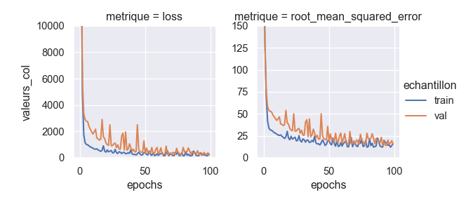

```python
perf(history_dense)
```

### 3.4.2 RNN

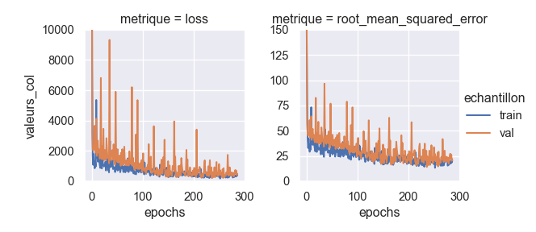

```python
perf(history_rnn)
```

### 3.4.3 GRU

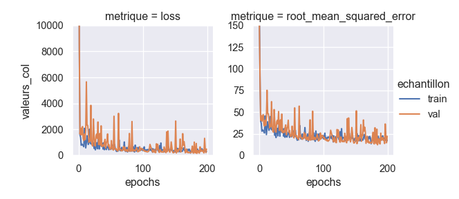

```python
perf(history_gru)
```

### 3.4.4 TCN

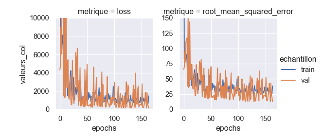

```python
perf(history_tcn)
```

## 3.5 Qualite de la prevision sur l’echantillon test

### 3.5.1 Regression

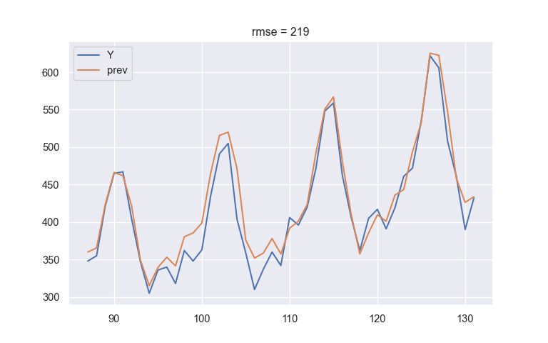

```python
dtf_Xcol["prev"] = model_lin.predict(dtf_Xcol[colonnes]); test = ~dtf_Xcol.partition
dtf_Xcol.loc[test, ["Y", "prev"]].plot();
plt.title(f"rmse = {rmse(dtf_Xcol.prev[test], dtf_Xcol.Y[test])}")
plt.show(ylim = (300, 650))
```

### 3.5.2 Couche Dense

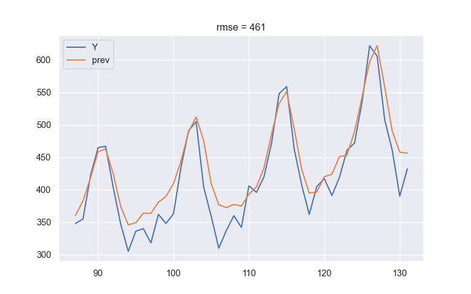

```python
dtf_Xcol["prev"] = model_dense.predict(dtf_Xcol[colonnes]);
dtf_Xcol.loc[test, ["Y", "prev"]].plot();
plt.title(f"rmse = {rmse(dtf_Xcol.prev[test], dtf_Xcol.Y[test])}")
plt.show(ylim = (300, 650))
```

### 3.5.3 RNN

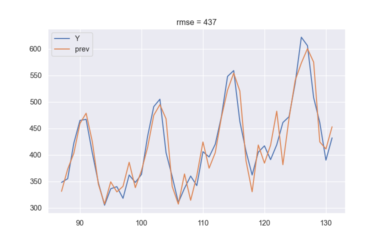

```python
X = np.concatenate((X_train, X_test))
dtf_Xlist["prev"] = model_rnn.predict(X); test = ~dtf_Xlist.partition
dtf_Xlist.loc[test, ["Y", "prev"]].plot();
plt.title(f"rmse = {rmse(dtf_Xlist.prev[test], dtf_Xlist.Y[test])}")
plt.show(ylim = (300, 650))
```

### 3.5.4 GRU

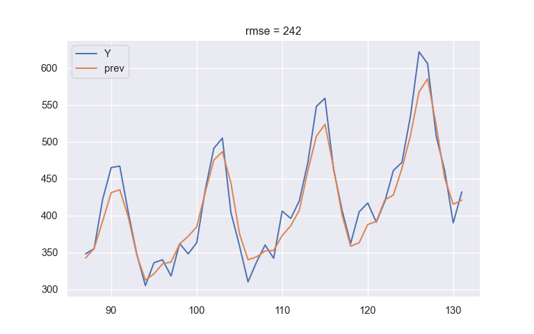

```python
dtf_Xlist["prev"] = model_gru.predict(X)
dtf_Xlist.loc[test, ["Y", "prev"]].plot();
plt.title(f"rmse = {rmse(dtf_Xlist.prev[test], dtf_Xlist.Y[test])}")
plt.show(ylim = (300, 650))
```

### 3.5.5 TCN

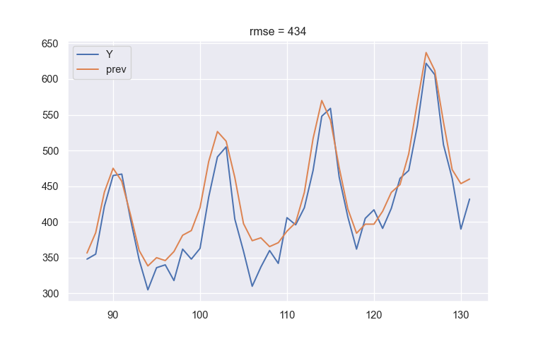

```python
dtf_Xlist["prev"] = model_tcn.predict(X)
dtf_Xlist.loc[test, ["Y", "prev"]].plot();
plt.title(f"rmse = {rmse(dtf_Xlist.prev[test], dtf_Xlist.Y[test])}")
plt.show(ylim = (300, 650))
```

# 4 Prevision en bloc des *L* mois suivants

On choisit `L = 12`.

## 4.1 Preparation des donnees

On prepare les donnees selon le meme schema que plus haut, avec *L* colonnes cibles au lieu d’une.

### 4.1.1 Couche Dense

```python
dtf_Xcol = donnees.copy()

for i in range(K-1):
  dtf_Xcol["X"+str(i+1)] =dtf_Xcol.X.shift(-i-1)

for i in range(L):
  dtf_Xcol["Y"+str(i+1)] =dtf_Xcol.X.shift(-K-i)

dtf_Xcol.dropna(inplace = True)

colonnesY = ["Y"+str(i+1) for i in range(L)]
Y_train = dtf_Xcol.loc[dtf_Xcol.partition, colonnesY].values

dtf_Xcol.drop(columns = colonnesY, inplace = True)

colonnes = ["X"] + ["X"+str(i+1) for i in range(K-1)]

train_dense = dtf_Xcol.loc[dtf_Xcol.partition, colonnes]
test_dense = dtf_Xcol.loc[~dtf_Xcol.partition, colonnes]
```

### 4.1.2 Couches Recurrentes

```python
dtf_Xlist = dtf_Xcol.copy()

dtf_Xlist["val_prec"] = dtf_Xlist[colonnes].values.tolist()
dtf_Xlist.drop(columns = colonnes, inplace = True)

X_train = list(dtf_Xlist.loc[dtf_Xlist.partition, "val_prec"])
X_test = list(dtf_Xlist.loc[~dtf_Xlist.partition, "val_prec"])

X_train = np.reshape(X_train, (len(X_train), K, 1))
X_test = np.reshape(X_test, (len(X_test), K, 1))
dtf_Xlist
```

```
        Month  partition    tendance   saisons   residus  \
0    1949 Jan       True   36.816081  0.912383  3.334289
1    1949 Feb       True   39.970048  0.847441  3.483678
2    1949 Mar       True   43.124016  1.001484  3.056404
3    1949 Apr       True   46.277983  0.977029  2.853038
4    1949 May       True   49.431950  0.984408  2.486580
..        ...        ...         ...       ...       ...
116  1958 Sep      False  402.676298  1.059261  0.947158
117  1958 Oct      False  405.830266  0.930246  0.950938
118  1958 Nov      False  408.984233  0.803905  0.942867
119  1958 Dec      False  412.138200  0.893732  0.914913
120  1959 Jan      False  415.292168  0.912383  0.950105

                                              val_prec
0    [112.0, 118.0, 132.0, 129.0, 121.0, 135.0, 148...
1    [118.0, 132.0, 129.0, 121.0, 135.0, 148.0, 148...
2    [132.0, 129.0, 121.0, 135.0, 148.0, 148.0, 136...
3    [129.0, 121.0, 135.0, 148.0, 148.0, 136.0, 119...
4    [121.0, 135.0, 148.0, 148.0, 136.0, 119.0, 104...
..                                                 ...
116  [404.0, 359.0, 310.0, 337.0, 360.0, 342.0, 406...
117  [359.0, 310.0, 337.0, 360.0, 342.0, 406.0, 396...
118  [310.0, 337.0, 360.0, 342.0, 406.0, 396.0, 420...
119  [337.0, 360.0, 342.0, 406.0, 396.0, 420.0, 472...
120  [360.0, 342.0, 406.0, 396.0, 420.0, 472.0, 548...

[121 rows x 6 columns]
```

## 4.2 Architecture et entrainement des modeles

### 4.2.1 Couche Dense

```python
model_dense2 = Sequential()
model_dense2.add(Dense(100, activation = 'relu', input_dim = len(colonnes)))
model_dense2.add(Dense(L))
model_dense2.compile(loss = "mean_squared_error", metrics = [tf.keras.metrics.RootMeanSquaredError()])

history_dense = model_dense2.fit(train_dense,
                    Y_train,
                    epochs = 100,
                    batch_size = 16,
                    verbose = 0,
                    validation_split = 0.3,
                    callbacks = [early_stopping])
```

### 4.2.2 RNN

```python
model_rnn2 = Sequential()
model_rnn2.add(SimpleRNN(260, activation='relu', input_shape = (K, 1)))
model_rnn2.add(Dropout(0.2))
model_rnn2.add(Dense(L))
model_rnn2.compile(loss = "mean_squared_error", metrics = [tf.keras.metrics.RootMeanSquaredError()])

history_rnn = model_rnn2.fit(X_train,
                    Y_train,
                    epochs = 300,
                    batch_size = 16,
                    verbose = 0,
                    validation_split = 0.3,
                    callbacks = [early_stopping])
```

### 4.2.3 GRU

```python
model_gru2 = Sequential()
model_gru2.add(GRU(256, activation='relu', input_shape = (K, 1)))
model_gru2.add(Dropout(0.2))
model_gru2.add(Dense(L))
model_gru2.compile(loss = "mean_squared_error", metrics = [tf.keras.metrics.RootMeanSquaredError()])

history_gru = model_gru2.fit(X_train,
                    Y_train,
                    epochs = 300,
                    batch_size = 16,
                    verbose = 0,
                    validation_split = 0.3,
                    callbacks = [early_stopping])
```

### 4.2.4 TCN

```python
tcn_layer = TCN(input_shape = (K, 1),
                nb_filters = 30,
                kernel_size = 3,
                dilations = (1, 2))

print('Receptive field size =', tcn_layer.receptive_field)

model_tcn2 = Sequential()
model_tcn2.add(tcn_layer)
model_tcn2.add(Dropout(0.2))
model_tcn2.add(Dense(L))
model_tcn2.compile(loss = "mean_squared_error", metrics = [tf.keras.metrics.RootMeanSquaredError()])

history_tcn = model_tcn2.fit(X_train,
                    Y_train,
                    epochs = 300,
                    batch_size = 16,
                    verbose = 0,
                    validation_split = 0.3,
                    callbacks = [early_stopping])
```

```
Receptive field size = 13
```

## 4.3 Performance lors de l’entrainement

### 4.3.1 Couche Dense

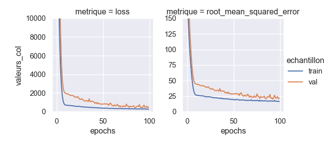

```python
perf(history_dense)
```

### 4.3.2 RNN

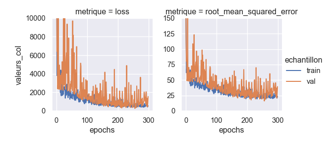

```python
perf(history_rnn)
```

### 4.3.3 GRU

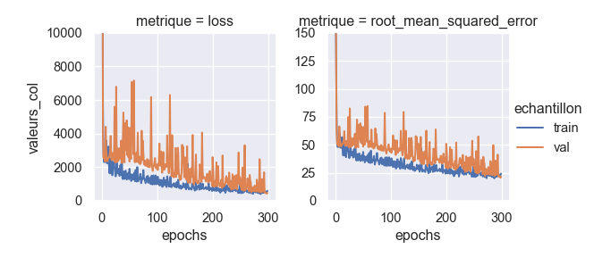

```python
perf(history_gru)
```

### 4.3.4 TCN

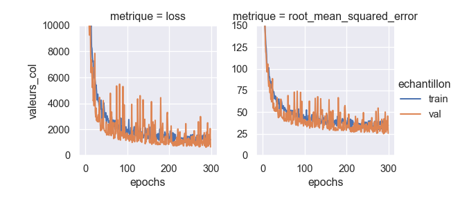

```python
perf(history_tcn)
```

## 4.4 Qualite de la prevision sur l’annee 1960

### 4.4.1 Couche Dense

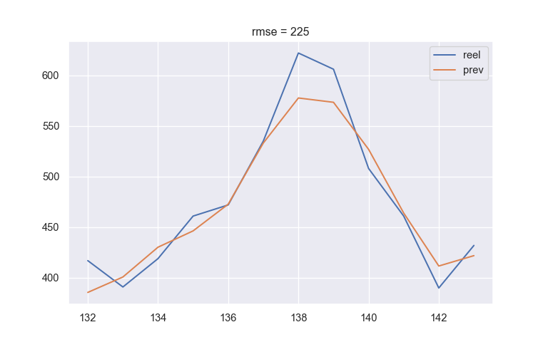

```python
resultats = pd.DataFrame({"reel": donnees.X[-L:],
                          "prev": np.squeeze(model_dense2.predict(dtf_Xcol.tail(1)[colonnes]))})
resultats.plot();
plt.title(f"rmse = {rmse(resultats.reel, resultats.prev)}")
plt.show(ylim = (300, 650))
```

### 4.4.2 RNN

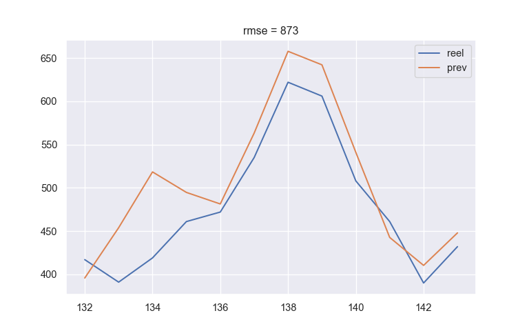

```python
test = np.reshape(X_test[-1,:], (1,L,1))
resultats = pd.DataFrame({"reel": donnees.X[-L:],
                          "prev": np.squeeze(model_rnn2.predict(test))})
resultats.plot();
plt.title(f"rmse = {rmse(resultats.reel, resultats.prev)}")
plt.show(ylim = (300, 650))
```

### 4.4.3 GRU

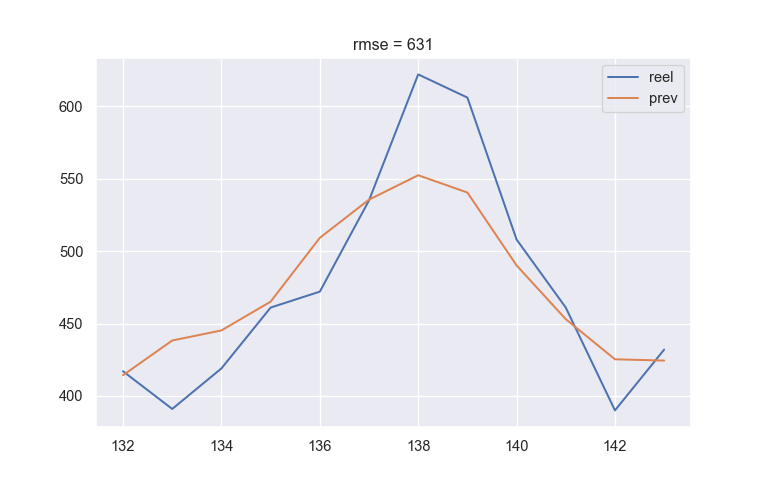

```python
resultats = pd.DataFrame({"reel": donnees.X[-L:],
                          "prev": np.squeeze(model_gru2.predict(test))})
resultats.plot();
plt.title(f"rmse = {rmse(resultats.reel, resultats.prev)}")
plt.show(ylim = (300, 650))
```

### 4.4.4 TCN

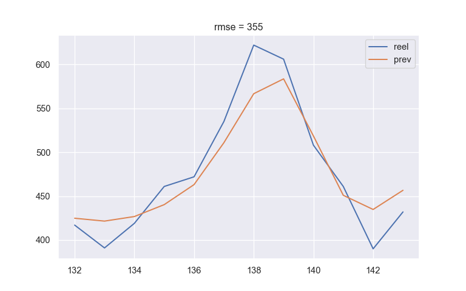

```python
resultats = pd.DataFrame({"reel": donnees.X[-L:],
                          "prev": np.squeeze(model_tcn2.predict(test))})
resultats.plot();
plt.title(f"rmse = {rmse(resultats.reel, resultats.prev)}")
plt.show(ylim = (300, 650))
```

# 5 Prevision iteree des *L* mois suivants

On reprend les modeles entraines pour predire la valeur suivante. Cette nouvelle valeur est ensuite consideree comme la derniere valeur connue, et on reapplique les modeles pour predire la valeur qui la suit, etc.

## 5.1 Calcul des previsions

### 5.1.1 Regression

```python
dernieres_valeurs = dtf_Xcol[colonnes].tail(1)
noms = dernieres_valeurs.columns

for i in range(L):
  prev = model_lin.predict(dernieres_valeurs)[0]
  decale_valeurs = dernieres_valeurs.values[0] .tolist()[1:]
  decale_valeurs.append(prev)
  dernieres_valeurs = pd.DataFrame(np.reshape(decale_valeurs, (1,12)), columns = noms)

prev_lin = dernieres_valeurs.values[0] .tolist()
```

### 5.1.2 Couche Dense

```python
dernieres_valeurs = dtf_Xcol[colonnes].tail(1)
noms = dernieres_valeurs.columns

for i in range(L):
  prev = model_dense.predict(dernieres_valeurs)[0][0]
  decale_valeurs = dernieres_valeurs.values[0] .tolist()[1:]
  decale_valeurs.append(prev)
  dernieres_valeurs = pd.DataFrame(np.reshape(decale_valeurs, (1,12)), columns = noms)

prev_dense =  dernieres_valeurs.values[0] .tolist()
```

### 5.1.3 RNN

```python
dims = X_test.shape
dernieres_valeurs = X_test[dims[0] - 1,:,0]
dernieres_valeurs = np.reshape(dernieres_valeurs, (1,K,1))

for i in range(L):
  prev = model_rnn.predict(dernieres_valeurs)[0][0]
  decale_valeurs = dernieres_valeurs[0,:,0].tolist()[1:]
  decale_valeurs.append(prev)
  dernieres_valeurs = np.reshape(decale_valeurs, (1,K,1))

prev_rnn =  dernieres_valeurs[0,:,0].tolist()
```

### 5.1.4 GRU

```python
dims = X_test.shape
dernieres_valeurs = X_test[dims[0] - 1,:,0]
dernieres_valeurs = np.reshape(dernieres_valeurs, (1,K,1))

for i in range(L):
  prev = model_gru.predict(dernieres_valeurs)[0][0]
  decale_valeurs = dernieres_valeurs[0,:,0].tolist()[1:]
  decale_valeurs.append(prev)
  dernieres_valeurs = np.reshape(decale_valeurs, (1,K,1))

prev_gru = dernieres_valeurs[0,:,0].tolist()
```

### 5.1.5 TCN

```python
dims = X_test.shape
dernieres_valeurs = X_test[dims[0] - 1,:,0]
dernieres_valeurs = np.reshape(dernieres_valeurs, (1,K,1))

for i in range(L):
  prev = model_tcn.predict(dernieres_valeurs)[0][0]
  decale_valeurs = dernieres_valeurs[0,:,0].tolist()[1:]
  decale_valeurs.append(prev)
  dernieres_valeurs = np.reshape(decale_valeurs, (1,K,1))

prev_tcn = dernieres_valeurs[0,:,0].tolist()
```

## 5.2 Qualite de la prevision sur l’annee 1960

### 5.2.1 Regression

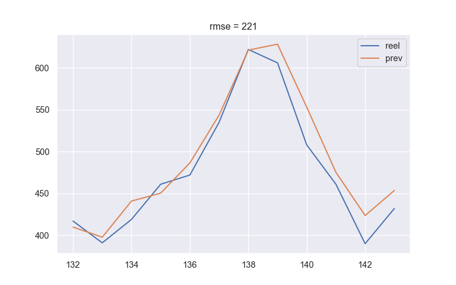

```python
resultats = pd.DataFrame({"reel": donnees.X[-L:], "prev": prev_lin})
resultats.plot();
plt.title(f"rmse = {rmse(resultats.reel, resultats.prev)}")
plt.show(ylim = (300, 650))
```

### 5.2.2 Couche Dense

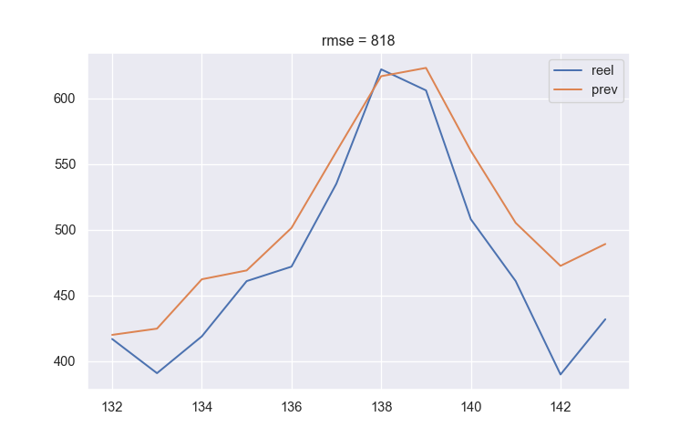

```python
resultats = pd.DataFrame({"reel": donnees.X[-L:], "prev": prev_dense})
resultats.plot();
plt.title(f"rmse = {rmse(resultats.reel, resultats.prev)}")
plt.show(ylim = (300, 650))
```

### 5.2.3 RNN

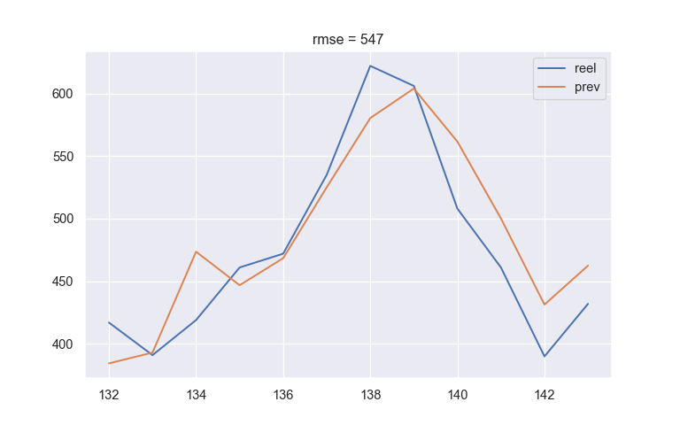

```python
resultats = pd.DataFrame({"reel": donnees.X[-L:], "prev": prev_rnn})
resultats.plot();
plt.title(f"rmse = {rmse(resultats.reel, resultats.prev)}")
plt.show(ylim = (300, 650))
```

### 5.2.4 GRU

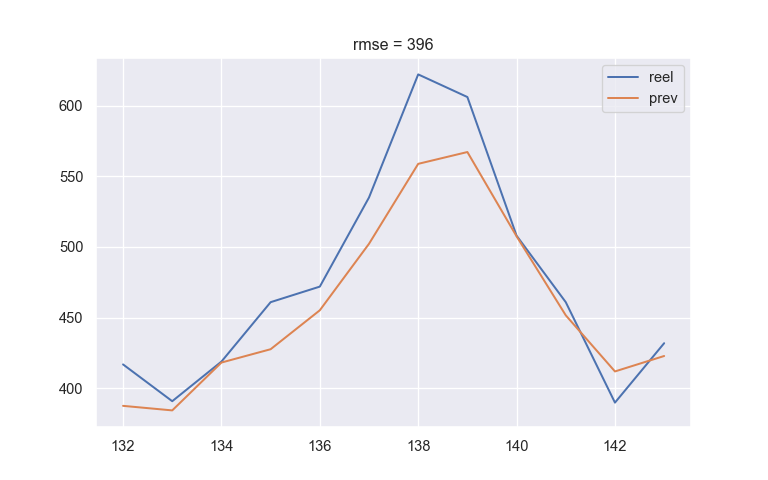

```python
resultats = pd.DataFrame({"reel": donnees.X[-L:], "prev": prev_gru})
resultats.plot();
plt.title(f"rmse = {rmse(resultats.reel, resultats.prev)}")
plt.show(ylim = (300, 650))
```

### 5.2.5 TCN

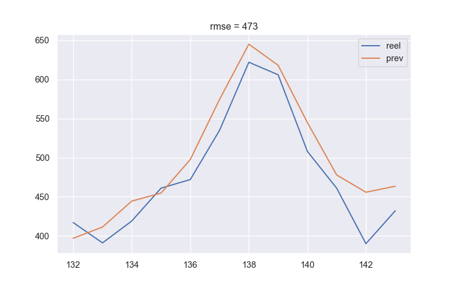

```python
resultats = pd.DataFrame({"reel": donnees.X[-L:], "prev": prev_tcn})
resultats.plot();
plt.title(f"rmse = {rmse(resultats.reel, resultats.prev)}")
plt.show(ylim = (300, 650))
```